# Homework 08

## Question 1: Boundary and margin

The normal vector $w=(0.8,0.6)$ has unit length. Consequently, the perpendicular distance to the boundary is $|f(x)|$, while the functional margin is $yf(x)$. I classify an observation as inside, on, or beyond its class’s margin according as $yf(x)<1$, $yf(x)=1$, or $yf(x)>1$.

```python
d1 = pd.read_csv("data/margin-geometry-20.csv")
d1["score"] = 0.8 * d1["x1"] + 0.6 * d1["x2"]
d1["distance"] = d1["score"].abs()
d1["functional margin"] = d1["y"] * d1["score"]
d1["position"] = np.select(
    [np.isclose(d1["functional margin"], 1), d1["functional margin"] < 1],
    ["on", "inside"],
    default="beyond",
)
display(
    d1[["observation", "x1", "x2", "y", "distance", "functional margin", "position"]]
    .style.format({"distance": "{:.2f}", "functional margin": "{:.2f}"})
)
```

|  | observation | x1 | x2 | y | distance | functional margin | position |
| --- | --- | --- | --- | --- | --- | --- | --- |
| 0 | 1 | 0.680000 | 0.760000 | 1 | 1.00 | 1.00 | on |
| 1 | 2 | 1.800000 | -0.150000 | 1 | 1.35 | 1.35 | beyond |
| 2 | 3 | 1.380000 | 0.660000 | 1 | 1.50 | 1.50 | beyond |
| 3 | 4 | 0.880000 | 1.660000 | 1 | 1.70 | 1.70 | beyond |
| 4 | 5 | 0.620000 | 2.340000 | 1 | 1.90 | 1.90 | beyond |
| 5 | 6 | 2.780000 | -0.040000 | 1 | 2.20 | 2.20 | beyond |
| 6 | 7 | 1.860000 | 1.520000 | 1 | 2.40 | 2.40 | beyond |
| 7 | 8 | 0.500000 | 0.400000 | 1 | 0.64 | 0.64 | inside |
| 8 | 9 | 0.100000 | 0.200000 | 1 | 0.20 | 0.20 | inside |
| 9 | 10 | -0.400000 | 0.200000 | 1 | 0.20 | -0.20 | inside |
| 10 | 11 | -0.920000 | -0.440000 | -1 | 1.00 | 1.00 | on |
| 11 | 12 | -0.500000 | -1.500000 | -1 | 1.30 | 1.30 | beyond |
| 12 | 13 | -1.900000 | -0.050000 | -1 | 1.55 | 1.55 | beyond |
| 13 | 14 | -0.440000 | -2.330000 | -1 | 1.75 | 1.75 | beyond |
| 14 | 15 | -1.980000 | -0.610000 | -1 | 1.95 | 1.95 | beyond |
| 15 | 16 | -2.740000 | 0.070000 | -1 | 2.15 | 2.15 | beyond |
| 16 | 17 | -1.900000 | -1.550000 | -1 | 2.45 | 2.45 | beyond |
| 17 | 18 | -0.500000 | -0.400000 | -1 | 0.64 | 0.64 | inside |
| 18 | 19 | 0.000000 | -0.400000 | -1 | 0.24 | 0.24 | inside |
| 19 | 20 | 0.400000 | -0.200000 | -1 | 0.20 | -0.20 | inside |

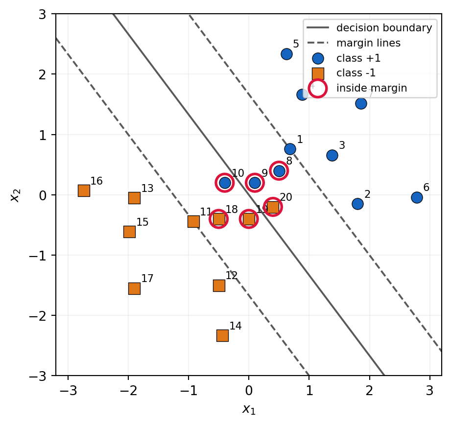

Figure 1: The fixed decision boundary and class-specific margin lines. Red rings mark observations inside their class’s margin; numbers are observation IDs.

```python
fig, ax = plt.subplots()
x1_grid = np.linspace(-3.2, 3.2, 300)
for level, style, label in [
    (0, "-", "decision boundary"),
    (1, "--", "margin lines"),
    (-1, "--", None),
]:
    ax.plot(x1_grid, (level - 0.8 * x1_grid) / 0.6,
            color="0.35", linestyle=style, linewidth=1.4, label=label)

for y_value, color, marker in [(1, "#1565c0", "o"), (-1, "#e07819", "s")]:
    subset = d1[d1["y"] == y_value]
    ax.scatter(subset["x1"], subset["x2"], c=color, marker=marker,
               s=75, edgecolors="black", linewidths=0.5, zorder=3,
               label=f"class {y_value:+d}")

inside = d1[d1["position"] == "inside"]
ax.scatter(inside["x1"], inside["x2"], facecolors="none", edgecolors="crimson",
           s=180, linewidths=2, zorder=4, label="inside margin")
for row in d1.itertuples(index=False):
    ax.annotate(str(row.observation), (row.x1, row.x2), xytext=(5, 5),
                textcoords="offset points", fontsize=8)

ax.set(xlim=(-3.2, 3.2), ylim=(-3, 3), xlabel="$x_1$", ylabel="$x_2$")
ax.set_aspect("equal", adjustable="box")
ax.grid(alpha=0.15)
ax.legend(loc="upper right", fontsize=8)
plt.show()
```

The counts are **6 inside** (observations 8, 9, 10, 18, 19, 20), **2 on** (1, 11), and **12 beyond** the margin. Observations **10 and 20** are misclassified because their functional margins are $-0.20<0$. Both are also inside their class’s margin under the requested $yf(x)<1$ rule.

## Question 2: Margin in four dimensions

Here $\|\boldsymbol\beta\|_2=\sqrt{1+4+4+16}=5$. For the unit direction $u=\boldsymbol\beta/5$, define the one-dimensional projection $t_i=x_i^{\mathsf T}u$. Then $f(x_i)=-1+5t_i$ and the decision boundary is at $t=0.2$.

```python
d2 = pd.read_csv("data/margin-geometry-4d.csv")
beta = np.array([1.0, 2.0, -2.0, 4.0])
beta0 = -1.0
norm_beta = np.linalg.norm(beta)
X2 = d2[["x1", "x2", "x3", "x4"]].to_numpy()
d2["t"] = X2 @ (beta / norm_beta)
d2["score"] = beta0 + X2 @ beta
d2["functional margin"] = d2["y"] * d2["score"]
boundary_t = -beta0 / norm_beta
min_functional = d2["functional margin"].min()
M = np.min(np.abs(d2["score"])) / norm_beta
closest = d2[np.isclose(np.abs(d2["score"]) / norm_beta, M)]
print(f"Projection coordinate of boundary: {boundary_t:.1f}")
print(f"Negative-class projection range: {d2.loc[d2.y == -1, 't'].min():.1f} to {d2.loc[d2.y == -1, 't'].max():.1f}")
print(f"Positive-class projection range: {d2.loc[d2.y == 1, 't'].min():.1f} to {d2.loc[d2.y == 1, 't'].max():.1f}")
print(f"Closest observation IDs: {closest.observation.tolist()}")
print(f"Geometric margin M: {M:.1f}")
```

```
Projection coordinate of boundary: 0.2
Negative-class projection range: -2.2 to -0.8
Positive-class projection range: 1.2 to 2.6
Closest observation IDs: [4, 15, 33, 36]
Geometric margin M: 1.0
```

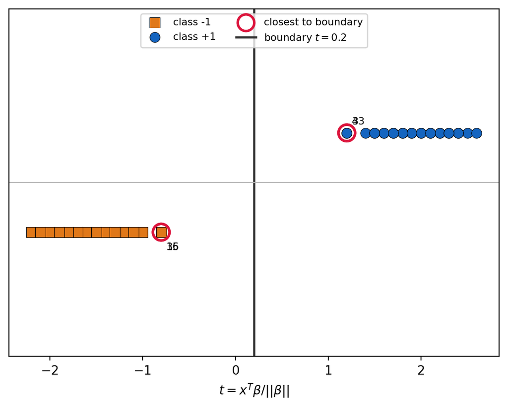

Figure 2: Projection onto the unit direction of beta. The short vertical offsets distinguish the two classes; horizontal position alone gives the projection. Circled points attain the geometric margin.

```python
fig, ax = plt.subplots()
for y_value, color, marker, offset in [(-1, "#e07819", "s", -0.08),
                                        (1, "#1565c0", "o", 0.08)]:
    subset = d2[d2["y"] == y_value]
    ax.scatter(subset["t"], np.full(len(subset), offset), color=color,
               marker=marker, edgecolors="black", linewidths=0.4,
               s=65, label=f"class {y_value:+d}", zorder=3)
ax.scatter(closest["t"], np.where(closest["y"] == 1, 0.08, -0.08),
           facecolors="none", edgecolors="crimson", s=175, linewidths=2,
           label="closest to boundary", zorder=4)
for row in closest.itertuples(index=False):
    ax.annotate(str(row.observation), (row.t, 0.08 if row.y == 1 else -0.08),
                xytext=(4, 7 if row.y == 1 else -14), textcoords="offset points",
                fontsize=8)
ax.axvline(boundary_t, color="0.2", linewidth=1.7, label="boundary $t=0.2$")
ax.axhline(0, color="0.7", linewidth=0.8)
ax.set(xlabel="$t=x^T\\beta/||\\beta||$", yticks=[], ylim=(-0.28, 0.28))
ax.legend(ncol=2, fontsize=8, loc="upper center")
plt.show()
```

The nearest negative observations have $t=-0.8$ (15 and 36), and the nearest positive observations have $t=1.2$ (4 and 33). Each is distance $1.0$ from $t=0.2$, so **$M=1$**. Every observation is classified correctly.

The smallest functional margin under the supplied coefficients is $5$. Dividing the score by $5$ preserves the boundary and makes that minimum $1$:

$$\beta_0^{\mathrm{SVM}}=-\frac15=-0.2,\qquad
\boldsymbol\beta^{\mathrm{SVM}}
=\frac15(1,2,-2,4)^\mathsf T
=(0.2,0.4,-0.4,0.8)^\mathsf T.$$

## Question 3: Peer review of a Homework 7 skill

The assigned repository is [nupurkalele1/stat432-fall2026](https://github.com/nupurkalele1/stat432-fall2026/tree/main/homework/week-07), as specified in [the instructor’s assignment Issue](https://github.com/ziqinice/stat432-fall2026/issues/3). I used the skill definition transcribed from the assigned Homework 7 report to analyze SAheart with `chd` as the response, the other nine columns as numeric predictors, `famhist` coded Absent = 1 and Present = 2, and seed 432. The skill run selected LDA under its one-standard-error rule; its reserved-test misclassification rate was 0.266 (37 of 139).

**Peer-review Issue:** [Homework 8 peer review of Homework 7 LDA/QDA skill, Issue #5](https://github.com/nupurkalele1/stat432-fall2026/issues/5). The review below is the same text posted there.

## Overall assessment

The skill gives a clear workflow for reserving a test set, comparing LDA/QDA candidates on shared cross-validation folds, and refitting preprocessing within each fold. The submitted analysis is reproducible and explains why plain LDA was selected under the one-standard-error rule. My independent Python run also selected LDA, although its reserved-test error was 0.266 rather than the report’s 0.302 because the data splits differed.

1. **Make the required one-page report complete.** The section labeled “One-page report” in the submitted PDF extends across pages 12 and 13. Its results table lists only four candidates, although the analysis compares 19 and the skill asks for a table of all candidates. Readers cannot check the full comparison from that table, and the report does not meet the skill’s page limit. I recommend using a smaller, fixed candidate grid or a more compact table that includes every candidate, then checking the printed page count before submission.
2. **Specify the candidate grid and split procedure in the skill.** The skill says that PCA dimensions and blend weights may be chosen from a “small grid,” but it does not define that grid. The author tested PCA dimensions 2–8, while my valid run used 3, 5, and 7; the two runs therefore compared different candidate sets. Even with seed 432, the R and Python stratified-split procedures produced different test sets and test errors (0.302 versus 0.266). This limits reproducibility across agents. I recommend listing the candidate values explicitly and specifying either the split indices or a language-independent rule for generating them.
3. **Require a diagnostic for missed CHD cases.** The skill uses misclassification rate as its only comparison metric, and the submitted report’s confusion matrix shows that the selected model missed 27 of 48 CHD cases (sensitivity 44%). My run missed 24 of 48 (sensitivity 50%). A single overall error rate can hide this practically important failure mode. I recommend keeping misclassification rate for model selection, as the skill intends, but requiring sensitivity and specificity alongside the final confusion matrix and a short discussion of the cost of missed cases.